# Deep Learning- 課程 27－Deep Learning- An introduction to SSD - Video / WebCam Part - 02 - 影像 目標檢測 - Python Tutorial

''' 人工智慧- 進階課程 A.I Tutorials - Advanced Course - Deep Learning 教程 ''' 05 - 深度學習 教程 課程 27 - Deep Learning- - An introduction to SSD - Part- 02 - Single Shot MultiBox Detection - Video / WebCam 程式範例 - SSD - Video / Webcam - 影像 目標檢測 ''' ''' >> 資料準備 >> 你我互動學習園地- 進階課程 Advanced Course >> https://interactiveuandmetutorialsac.weebly.com/ >> 你我互動學習園地 >> https://interactiveuandmetutorials.weebly.com/ >> Python 程式語言 設計 >> https://pythonprogrammingtutorials.weebly.com/ >> 目錄結構 : >> Deep Learning- 課程 27－Deep Learning- An introduction to SSD - Video / WebCam Part - 02 - 影像 目標檢測.zip 檔案路徑/ ├── 課程 27－Deep Learning- Single Shot MultiBox Detector -SSD -介紹 - Video / Webcam - 影像 目標檢測 .ipynb | ├── bounding_box_utils| | ├── __init__.py | └── bounding_box_utils.py | ├── keras_layers | ├── __init__.py | ├── keras_layer_AnchorBoxes.py | ├── keras_layer_DecodeDetections.py | ├── keras_layer_DecodeDetectionsFast.py | └── keras_layer_L2Normalization.py | ├── keras_loss_function | ├── __init__.py | └── keras_ssd_loss.py ├── models | └── keras_ssd512.py ├── weights | └── VGG_VOC0712Plus_SSD_512x512_ft_iter_160000.h5 ├── inputs | ├── images | | └── XXX.jpg | └── videos | └── XXX.mp4 ├── outputs | ├── images | | └── XXX.jpg | └── videos | └── XXX.mp4 ├── test_images | ├── images | | └── XXX.jpg | └── videos | └── XXX.mp4 | ├── test_imagesout | ├── images | | └── XXX.jpg | └── videos | └── XXX.mp4 └── model.h5 '''

- SSD Single Shot MultiBox Detector - Paper 論文參考
  - https://arxiv.org/pdf/1512.02325.pdf

''' SSD - Single Shot MultiBox Detector - YoLo -> V3 版本以前 - 有個小逅病 - 對於小物件的偵測效果不佳 - 在 V3 時 - 提出方法改善 - SSD - 是怎麼 - 對於小物件的偵測 - 不會隨著網路層數越深變差 - 當網路層數越深 - 由於小物件 - 經過多次的 Convolution 迭代 - 經過越多層 - 能留下來的訊息就會越來越小 - 導致最後對於小物體的效果 , 不是很明顯. - SSD 的 網路架構 - 首先會先經過 VGG16 的 神經網路 - 接著加上一層 Layer Norm 與 一些 Convolution -> 加深網路 - 這 與 一般加深神經網路 -> 有什麼不一樣呢 ？ - 原來是最後要進行輸出時 - 並不會只取最後的輸出 - 而是會將在幾層卷積層的輸出合併起來, 一起來輸出 - 這樣越前面 - 的卷積層 -> 對小物件的訊息掌握度高 - 越後面 - 的卷基層 -> 也可以掌握大物件的訊息 - 分別將 l2Norm, Conv7, Conv8_2, Conv9_2, Conv10_2, Conv11_2 的輸出 - 輸入到 Mutlilayer '''

```python
- SSD
```

[figure not shown]

- YoLoV1/YoLoV2/YoLoV3

[figure not shown]

- YoLov3

[figure not shown]

- SSD Single Shot MultiBox Detector

[figure not shown]

''' - SSD - Single Shot MultiBox Detector - 沒有 - 區域提議網絡 - Region Proposal Network - 僅一次 通過功能 - Feature Maps - 直接預測 - 邊界框 - Boundary Boxes - 類 - Classes - 為了提高準確性 - Improve Accuracy - SSD 引入 - 小型捲積濾波器 - Small Convolutional Filters - 用於預測 - 對像類別 - 默認邊界框 - 偏移量 Offset - 默認框 - 單獨過濾器 - Separate FiltersDefault Boxes - 處理寬高比的差異 - Difference in Sspect Ratios - 對象檢測 - 多尺度特徵圖 - Multi Scale Feature Maps - 端到端 End-To-End - SSD 進行培訓 - 提高準確性 - SSD - 更多預測 - 更好地覆蓋 Cover - 位置 , 比例 , 寬高比 - Location, Scale and Aspect Ratios - 上述改進 - SSD - 將輸入圖像分辨率 - 降低到 300 × 300 - 相對準確的性能 - 通過刪除 委託區域提案 - 並使用較低分辨率的圖像 - SSD 模型可以 - In Time - 運行 - 優於 > Faster R-CNN '''

[figure not shown]

''' >> Single Shot MultiBox Detector - SSD 專為 Real-Time 目標檢測 - 設計 >> 區域卷積神經網絡 - R-CNN - Region - Convolutional Neural Network (R-CNN) >> 區域提議網絡 - Region Proposal Wetwork - 創建邊界框 - Boundary Boxes - 這些框對 對象 - 進行分類 - Classify Objects >> SSD - 被認為-> 是最先進的準確性 - Accuracy - 每秒 7 幀 -7 Frames Per Second - SSD - 拿掉 - 區域提議網絡 - Region Proposal Network - 需求 - 加快 - 該檢測過程 - 恢復 Recover - 準確性下降 - 使用- 較低分辨率的圖像 300 × 300 - Lower Resolution Images - SSD - 進行一些改進 - 包括 - 多尺度功能 - Multi Scale Features - Default Boxes >> 準確度 - 平均準確度 - mAP - Mean Average Precision mAP - 預測 - 準確度 - Precision Of The Predictions '''

[figure not shown]

''' >> SSD: Single Shot MultiBox Detector - 提取特徵圖 - Extract feature maps - 卷積過濾器 - 檢測對象 - Convolution Filters - Detect Objects >> SingleMultiBox檢測器 - Architechture 結構 - 輸入 - 300 x 300 x 3 '''

[figure not shown]

''' >> SSD - 結構 - 建立在 - VGG-16 上 - 丟棄了 - 完全連接的層 FC Layer - VGG-16 用作- 基礎網絡的原因 - 由於在高質量圖像 - 分類任務中 - 強大性能 - 傳輸學習 -助於 改善結果的問題中 - 廣泛應用 - 代替原始的 VGG 全連接層 - Fully Connected Layers - 添加了一組輔助卷積層- 從 conv 6 開始 - 能夠以多個比例 - Extract Features - 提取特徵 - Extract Features - 逐漸減小每個後續層 - 輸入大小 '''

- VGG16

[figure not shown]

- SSD

[figure not shown]

''' - SSD - VGG16 提取特徵圖 - Extract Feature Maps '''

[figure not shown]

''' - VGG16 網絡 - 結構 '''

[figure not shown]

''' - Detects Objects - Conv4_3 Layer - 檢測對象 - 8 × 8 - 38 × 38 - 每個單元格 Each Cell - 位置 - Location - 對象預測 - Object Predictions - 4 個 Units '''

[figure not shown]

''' - 每個預測 - 由 - 一個邊界框 - 每個類的 21個 - 得分 Scores - 組成 - 沒有對象的 - 額外一個類 - 選擇最高得分 - 作為 - 有 - 對象的類 - SSD - 保留 - Classs " 0 " - 表示 - 沒有對象 - SSD Reserves a class " 0 " - " indicate it has no objects - - 每個預測 - 包括一個邊界框 21個 類 - 21個 得分 - 一個類 - 沒有對象 - 多框 - Multi-Box - 進行包含 - 邊界框 - Boundary Boxes - 置信度分數 - Confidence Scores - 多個預測 - Multiple Predictions '''

[figure not shown]

''' - 目標檢測 Object Detection - 捲積預測 - Convolutional Predictors - SSD - 不使用 -區域提議網絡 - Not Use Region Proposal Network - 簡單的方法 -Very Simple Method - Small Convolution Filters - Computing - Location - Class Scores - 提取特徵圖後 - Extracting the Feature Maps - 每個單元 Each Cell - 3×3卷積濾波器 - Convolution Filters - 進行預測 - Predictions - Each Filter Outputs - 25 channels - 每個類別 Each Class - 21 Scores - 一個邊界框 Boundary Box - One '''

''' - 3x3 卷積濾波器 - Convolution Filter - 位置 - Location - 類別 - Class - 進行預測 - Conv4_3 - - 4 個 - 3×3 濾波器 - 512 個 - 輸入通道映射 - 25 個 - 輸出通道 '''

[figure not shown]

''' - 目標檢測 - Objects Detection - 多尺度特徵圖 - Multi-scale feature maps - 多尺度特徵圖 - 獨立檢測對象 - 隨著 - CNN - 逐漸減小 - 空間尺寸 - 特徵圖 - 分辨率 - 也會降低 - SSD - 較低分辨率的圖層 - 檢測 較大規模的對象 - 例如 - 4×4 特徵圖 - 用於 較大 比例 的對象 - 較低分辨率的特徵圖（右） - 可檢測較大比例的對象 '''

[figure not shown]

''' - SSD - VGG16 之後 - 增加了 - 6個 - 輔助 -> 卷積層 - 其中五個 - 將 添加 - 用於對象檢測 - 其中的三個層中 - 做出 6個預測 - 而不是 4個 - SSD - 使用 - 6 個層 - 做出 - 8732 個 - Objects 預測 '''

[figure not shown]

''' >> 多尺度特徵圖 - Multi Scale Feature Map 優點 - 提高了準確性 - Accuracy - 用於對象檢測 - 不同數量的 - 特徵圖圖層的準確性 - Accuracy - Different Number of Feature Map Layers '''

[figure not shown]

''' - 默認邊界框 - Default Boundary Box - Faster R-CNN中 - 錨點 Anchors '''''' - 預測邊界框 - 深度學習一樣 - 隨機預測 - 開始 - 梯度下降 - 優化模型 - 初始訓練期間 - 模型可能會 - 相互競爭 - 確定要 - 針對哪些預測優化的形狀（行人或汽車） - 早期訓練 - 可能非常不穩定 - 下面的邊界框預測 - 適用於一種類別 - 但不適 - 用於 - 其他類別 '''

[figure not shown]

''' - 如果 - 預測涵蓋了 - 更多形狀 - 例如 -更多形狀 - 涵蓋了更多的 - 對像類型 - Object Types - 模型可以檢測到更多的對像類型 - 訓練 - 變得更加 - 輕鬆 和 穩定 '''

[figure not shown]

''' - 現實中 - Real-Life - 邊界框 - Boundary Boxes - 沒有任意形狀和大小 - 汽車的形狀 - 相似 - 汽車 / 行人的 - 長寬比 約為 - 0.41 - Aspect Ratio of 0.41 - 自動駕駛中 - KITTI 數據集中 - 邊界框 Boundary Boxes的 寬度和 高度分佈 - 高度聚集 - Clustered '''

[figure not shown]

''' - 邊界框劃分為 - 群集 Cluster - 每個群集由 - 默認邊界框（群集的質心）表示 - k-means Cluster - 進行 - 隨機猜測外 - 猜測 - 這些默認框 - SSD 可以將默認框 - 保持為最小值 - 4 或 6 - 每個默認框 - 具有一個預測 - 邊界框預測 -相對於每個單元格的 默認邊界框（∆cx，∆cy，w，h） - 而不是對框位置使用全局坐標 - Global Coordination - 相對於 - 每個單元格的默認框 Default Box - 偏移量 - Offsets '''

[figure not shown]

''' - 每個特徵圖- 圖層 Each Feature Map Layers - 共享 相應單元為中心的 - 同一組默認框 - Shares the same set of default boxes centered at the corresponding cell - 不同的圖層 - 使用不同的默認框集來自定義不同分辨率的對象檢測 - Different layers use different sets of default boxes - customize object detections at different resolutions - 4個 綠色框 - 4個 - 默認邊界框 - 4 Green Boxes - 4 Default Boundary Boxes '''

[figure not shown]

''' - 選擇默認邊界框 - 手動選擇 '''

[figure not shown]

''' - SSD - 為 每個特徵圖 - 圖層定義了一個比例值 - 左側開始 - Conv4_3 - 最小比例0.2（有時為0.1）- 檢測對象 - 然後 - 0.9的比例 - 線性增加 到最右邊的圖層 - 結合比例值和目標 縱橫比 - 計算 默認框的 寬度 和 高度 - 做出 - 6 個預測 - 圖層 - SSD - 5 個目標 - 縱橫比 - 1 , 2 , 3 ,1/2 ,1/3 - 默認框的 寬度和 高度計算 '''

[figure not shown]

''' - 長寬比 = 1 - YOLO - 訓練數據集 - 使用 k-means 聚類 - 確定 默認邊界框 - Default Boundary Boxes '''

''' - 匹配 - Matching - SSD 預測分類 - Predictions are Classified - 正匹配 Positive matches - 不匹配 Negative matches - 相應的 默認邊界框（而非預測邊界框） - IoU 大於 > 0.5 - 基於地面實況 - 匹配為正 - 否則為負 - IoU - 聯合的交集 - 兩個區域 - 相交區域 與 合併區域 - 之間的比率 '''

[figure not shown]

''' >> 真實對象- 藍色 和 3個 默認邊界框 - 綠色 - Ground truth object (Blue) - 3 Default Boundary Boxes (Green) '''

[figure not shown]

''' - 簡化 - 為 3個 默認框 - 只有默認框 1 和 2 - 不是3 - IoU 大於 > 0.5 - 方框 1 和 2 - 是 - 正匹配 - Positive matches - 一旦確定了 - 正面匹配 -使用相應的預測邊界框 - 計算成本 - Calculate Cost - 匹配策略 - 每個預測 - 預測更接近相應默認框的形狀 - 因此 - 預測在訓練中 - 更加多樣化和穩定 '''

[figure not shown]

''' >> 多比例 特徵圖 要素 - Multi-Scale Feature Maps - 默認邊界框 - Default Boundary Boxes >> SSD 結合 - 多尺度特徵圖 和 默認邊界框 - 檢測不同尺度的對象的 >> 下面 - 狗 與 4×4要素 特徵圖 中 - 的一個默認框（紅色）匹配 - 但與高分辨率 8 × 8要素圖中 - 的任何默認框都不匹配 - 由2 個默認框中 - 8×84×4要素 特徵圖（藍色） - 檢測 到較小的貓 '''

[figure not shown]

''' >> 高分辨率特徵圖 - 負責檢測小物體 - 對象檢測 - 第一層 conv4_3的 空間尺寸 - 38×38 - 與輸入圖像相比 - 有很大的減小 >> 其他 - 檢測方法相比 - SSD 通常對小物體的性能較差 - 如果有問題 - 可以使用 - 更高分辨率的圖像 - Images with Higher Resolution - 來解 '''

[figure not shown]

''' >> 資料擴充 - Data augmentation - 數據擴充對於提高準確性 - 很重要 - 翻轉 Flipping - 裁切 Cropping - 顏色失真 Color Distortion - 增強數據 >> 每個訓練圖像 - 隨機採樣 - Sampling Original - 原版 - Sampling Original - IoU of 0.1, 0.3, 0.5, 0.7 or 0.9 - Sample a Patch - 隨機採樣 - Randomly sample a patch >> Patch 採樣 - Sample Patch - 長寬比 - (1/2 - 2 ) 之間 >> 將其調整為固定大小 - Fix Size - 訓練數據 - 翻轉一半 - Flip One- Falf etc .. '''

[figure not shown]

''' - 數據擴充後的 - 對於 - 性能改進 - Data Augmentation - Performance Improvement '''

[figure not shown]

''' - 預測 / 推斷時間 - Inference time - SSD - 預測 - 8732 - 覆蓋 -> 位置 -> 比例 -> 縱橫比 - 一些 預測 沒有對象 - 因此 - 類別置信度得分 - 低於0.01 的預測 - 移除 - Eliminated - SSD - 做出更多預測 - 使用較低分辨率的圖像 - 提升預測類別 - 精度 - Accuracy '''

[figure not shown]

''' - SSD - 非最大抑制 - Non-Maximum Suppression - nms - 非最大抑制 - 刪除 - 同一對象的 - 重複預測 - 通過 - 置信度分數 CS - 對預測 - 進行排序 - 最高置信度預測開始 - 根據同一類別的當前預測 - 評估是否先前預測的邊界框的 - IoU 高於 > 0.45 - 如果找到 - 則當前預測將被忽略 - 最多 - 保留每個圖像的 - 前 200 個 - 預測 '''

[figure not shown]

- SSD - Single Shot MultiBox Detector -SSD
  - 速度性能 每秒幀- Speed Performance
  - Frame Per Second speed performance 每秒幀速度性能
- SSD Paper
  - https://arxiv.org/pdf/1512.02325.pdf

[figure not shown]

# 程式範例

- 忽略 警告訊息 Warning Message

```python
import warnings
warnings.filterwarnings("ignore")
```

- 檢查是否 - 有 GPU

```python
from tensorflow.python.client import device_lib
print (device_lib.list_local_devices())
```

```
[name: "/device:CPU:0"
device_type: "CPU"
memory_limit: 268435456
locality {
}
incarnation: 5471223636059030996
, name: "/device:GPU:0"
device_type: "GPU"
memory_limit: 3176441446
locality {
  bus_id: 1
  links {
  }
}
incarnation: 8219487502216548085
physical_device_desc: "device: 0, name: GeForce GTX 980M, pci bus id: 0000:01:00.0, compute capability: 5.2"
]
```

- os.environ 在 Jupyter Notebok 中 - 設置環境變量
- 初始化TensorFlow
  - 將 TensorFlow 限制為第一個GPU之前

```python
import os
os.environ["CUDA_DEVICE_ORDER"]="PCI_BUS_ID"
os.environ["CUDA_VISIBLE_DEVICES"]="0"
```

```python
!python -V
```

```
Python 3.6.7
```

```python
import keras
print(keras.__version__)
```

```
2.2.4
```

  ```
    - Pre-Trained Weights - .h5 files
  ```

  - VGG_VOC0712Plus_SSD_512x512_ft_iter_160000.h5
    - https://drive.google.com/file/d/1a-64b6y6xsQr5puUsHX_wxI1orQDercM/view
- 安裝 / 導入
  - Install/ Import 所需的庫 - required libraries
- Ploting Relative Module

```python
%matplotlib inline
from matplotlib import pyplot as plt
import numpy as np
import imageio
from imageio import imread
import os
import cv2
```

- Keras Module

```python
from keras import backend as K
from keras.preprocessing import image
from keras.optimizers import Adam
from keras.models import load_model

import os
import cv2
```

- Custom Module

```python
from models.keras_ssd512 import ssd_512
from keras_loss_function.keras_ssd_loss import SSDLoss
```

```python
# Defining confidence threshold
confidence_threshold = 0.5

# Different Classes of objects in VOC dataset
classes = ['background',
           'aeroplane', 'bicycle', 'bird', 'boat',
           'bottle', 'bus', 'car', 'cat',
           'chair', 'cow', 'diningtable', 'dog',
           'horse', 'motorbike', 'person', 'pottedplant',
           'sheep', 'sofa', 'train', 'tvmonitor']
```

- 設置 圖像 Image 尺寸

```python
height = 512
width  = 512
```

```python
K.clear_session() # 清除 記憶體 - 之前的模型
```

- 建立模型
  - 已訓練 的權重 加載到 模型中
- 1 建立模型

```python
K.clear_session() # 清除 記憶體 - 之前的模型
```

```python
# creating model and loading pretrained weights
model = ssd_512(image_size=(height, width, 3),	# dimensions of the input images (fixed for SSD512)
                n_classes=20,	# Number of classes in VOC 2007 & 2012 dataset
                mode='inference',
                l2_regularization=0.0005,
                scales=[0.07, 0.15, 0.3, 0.45, 0.6, 0.75, 0.9, 1.05],
                aspect_ratios_per_layer=[[1.0, 2.0, 0.5],
                                         [1.0, 2.0, 0.5, 3.0, 1.0/3.0],
                                         [1.0, 2.0, 0.5, 3.0, 1.0/3.0],
                                         [1.0, 2.0, 0.5, 3.0, 1.0/3.0],
                                         [1.0, 2.0, 0.5, 3.0, 1.0/3.0],
                                         [1.0, 2.0, 0.5],
                                         [1.0, 2.0, 0.5]],
               two_boxes_for_ar1=True,
               steps=[8, 16, 32, 64, 128, 256, 512],
               offsets=[0.5, 0.5, 0.5, 0.5, 0.5, 0.5, 0.5],
               clip_boxes=False,
               variances=[0.1, 0.1, 0.2, 0.2],
               normalize_coords=True,
               subtract_mean=[123, 117, 104],
               swap_channels=[2, 1, 0],
               confidence_thresh=0.5,
               iou_threshold=0.45,
               top_k=200,
               nms_max_output_size=400)
```

- 2: 已訓練 的權重 加載到 模型中

```python
# path of the pre trained model weights
weights_path = 'weights/VGG_VOC0712Plus_SSD_512x512_ft_iter_160000.h5'
model.load_weights(weights_path, by_name=True)
```

- 編譯 模型 Compiling SSD The Model

```python
# Compiling the model
adam = Adam(lr=0.001, beta_1=0.9, beta_2=0.999, epsilon=1e-08, decay=0.0)
ssd_loss = SSDLoss(neg_pos_ratio=3, alpha=1.0)
model.compile(optimizer=adam, loss=ssd_loss.compute_loss)
```

```python
model.summary()
```

```
__________________________________________________________________________________________________
Layer (type)                    Output Shape         Param #     Connected to
==================================================================================================
input_1 (InputLayer)            (None, 512, 512, 3)  0
__________________________________________________________________________________________________
identity_layer (Lambda)         (None, 512, 512, 3)  0           input_1[0][0]
__________________________________________________________________________________________________
input_mean_normalization (Lambd (None, 512, 512, 3)  0           identity_layer[0][0]
__________________________________________________________________________________________________
input_channel_swap (Lambda)     (None, 512, 512, 3)  0           input_mean_normalization[0][0]
__________________________________________________________________________________________________
conv1_1 (Conv2D)                (None, 512, 512, 64) 1792        input_channel_swap[0][0]
__________________________________________________________________________________________________
conv1_2 (Conv2D)                (None, 512, 512, 64) 36928       conv1_1[0][0]
__________________________________________________________________________________________________
pool1 (MaxPooling2D)            (None, 256, 256, 64) 0           conv1_2[0][0]
__________________________________________________________________________________________________
conv2_1 (Conv2D)                (None, 256, 256, 128 73856       pool1[0][0]
__________________________________________________________________________________________________
conv2_2 (Conv2D)                (None, 256, 256, 128 147584      conv2_1[0][0]
__________________________________________________________________________________________________
pool2 (MaxPooling2D)            (None, 128, 128, 128 0           conv2_2[0][0]
__________________________________________________________________________________________________
conv3_1 (Conv2D)                (None, 128, 128, 256 295168      pool2[0][0]
__________________________________________________________________________________________________
conv3_2 (Conv2D)                (None, 128, 128, 256 590080      conv3_1[0][0]
__________________________________________________________________________________________________
conv3_3 (Conv2D)                (None, 128, 128, 256 590080      conv3_2[0][0]
__________________________________________________________________________________________________
pool3 (MaxPooling2D)            (None, 64, 64, 256)  0           conv3_3[0][0]
__________________________________________________________________________________________________
conv4_1 (Conv2D)                (None, 64, 64, 512)  1180160     pool3[0][0]
__________________________________________________________________________________________________
conv4_2 (Conv2D)                (None, 64, 64, 512)  2359808     conv4_1[0][0]
__________________________________________________________________________________________________
conv4_3 (Conv2D)                (None, 64, 64, 512)  2359808     conv4_2[0][0]
__________________________________________________________________________________________________
pool4 (MaxPooling2D)            (None, 32, 32, 512)  0           conv4_3[0][0]
__________________________________________________________________________________________________
conv5_1 (Conv2D)                (None, 32, 32, 512)  2359808     pool4[0][0]
```

[output cut: 148 more lines]

```
                                                                 conv7_2_mbox_priorbox_reshape[0][
                                                                 conv8_2_mbox_priorbox_reshape[0][
                                                                 conv9_2_mbox_priorbox_reshape[0][
                                                                 conv10_2_mbox_priorbox_reshape[0]
__________________________________________________________________________________________________
predictions (Concatenate)       (None, 24564, 33)    0           mbox_conf_softmax[0][0]
                                                                 mbox_loc[0][0]
                                                                 mbox_priorbox[0][0]
__________________________________________________________________________________________________
decoded_predictions (DecodeDete (None, <tf.Tensor 't 0           predictions[0][0]
==================================================================================================
Total params: 27,188,676
Trainable params: 27,188,676
Non-trainable params: 0
__________________________________________________________________________________________________
```

- Save Model - Model.h5

```python
model.save('model.h5')
```

```python
input_image_path =  'test_images'
output_image_path = 'test_imagesout'
```

```python
input_video_path =  'inputs/videos'
output_video_path = 'outputs/videos'
```

```python
# Transforming image size
def transform(input_image):
	return cv2.resize(input_image, (512, 512), interpolation = cv2.INTER_CUBIC)
```

```python
# Function to detect objects in image
def detect_object(original_image):
	original_image_height, original_image_width = original_image.shape[:2]
	input_image = transform(original_image)
	input_image = np.reshape(input_image, (1, 512, 512, 3))
	y_pred = model.predict(input_image)
	actual_prediction = [y_pred[k][y_pred[k,:,1] > confidence_threshold] for k in range(y_pred.shape[0])]
	for box in actual_prediction[0]:
		# Coordinates of diagonal points of bounding box
		x0 = box[-4] * original_image_width / width
		y0 = box[-3] * original_image_height / height
		x1 = box[-2] * original_image_width / width
		y1 = box[-1] * original_image_height / height
		label_text = '{}: {:.2f}'.format(classes[int(box[0])], box[1])	# label text
		cv2.rectangle(original_image, (int(x0), int(y0)), (int(x1), int(y1)), (255, 0, 0), 2)	# drwaing rectangle
		cv2.putText(original_image, label_text, (int(x0), int(y0)), cv2.FONT_HERSHEY_DUPLEX, 1, (231, 237, 243), 2, cv2.LINE_AA) # putting lable
	return original_image
```

```python
%%time

# Detecting objects in images
for file in os.listdir(input_image_path):
	print('Reading', file)
	original_image = imageio.imread(os.path.join(input_image_path, file))	# Reading image
	if original_image is not None:
		output_image = detect_object(original_image)	# detecting objects
		imageio.imwrite(os.path.join(output_image_path, file), output_image[:, :, :])	# savinng back images
```

```
Reading dog.jpg
Reading person.jpg
Reading zebra.jpg
Wall time: 3.24 s
```

```python
%%time

# Detecting objects in video
for file in os.listdir(input_video_path):
	print('Reading', file)
	video_reader = imageio.get_reader(os.path.join(input_video_path, file))	# Reading video
	fps = video_reader.get_meta_data()['fps']	# gettinf fps of the image
	video_writer = imageio.get_writer(os.path.join(output_video_path, file), fps = fps)	# Writing back output image
	for i, frame in enumerate(video_reader):
		output_frame = detect_object(frame)	# detecting objects frame by frame
		video_writer.append_data(output_frame)	# appending frame to vidoe
		print('frame ', i, 'done')
	video_writer.close()
```

[output not shown]

[output cut: 297 more lines]

```
frame  336 done
frame  337 done
frame  338 done
frame  339 done
frame  340 done
frame  341 done
frame  342 done
frame  343 done
frame  344 done
frame  345 done
frame  346 done
frame  347 done
frame  348 done
frame  349 done
Wall time: 38.1 s
```

# Image Detecting

- 圖像 偵測 - Image Detection
- 查看原始照片
  - Review Orginal Phote

```python
import cv2
cv2.__version__
```

```
'4.1.2'
```

```python
import cv2
import numpy as np
import matplotlib.pyplot as plt
%matplotlib inline
```

```
(424, 640, 3)
```

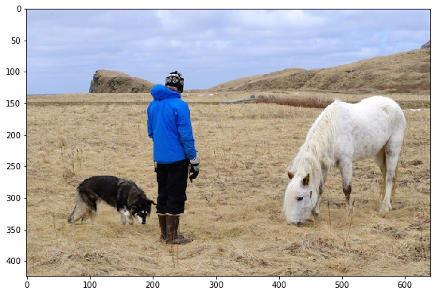

```python
img = cv2.imread('test_images/person.jpg')
img = cv2.cvtColor(img, cv2.COLOR_BGR2RGB)
plt.figure(figsize = (20, 20))
plt.subplot(1, 2, 1); plt.imshow(img)
img.shape
```

```
(576, 768, 3)
```

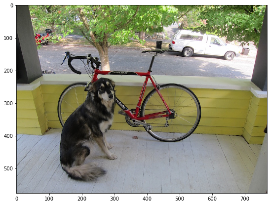

```python
img = cv2.imread('test_images/dog.jpg')
img = cv2.cvtColor(img, cv2.COLOR_BGR2RGB)
plt.figure(figsize = (20, 20))
plt.subplot(1, 2, 1); plt.imshow(img)
img.shape
```

```
(386, 640, 3)
```

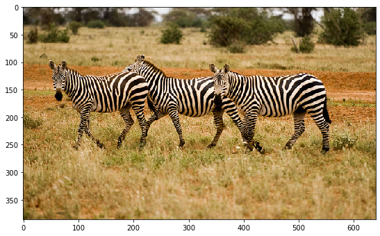

```python
img = cv2.imread('test_images/zebra.jpg')
img2 = cv2.cvtColor(img, cv2.COLOR_BGR2RGB)
plt.figure(figsize = (20, 20))
plt.subplot(1, 2, 1); plt.imshow(img2)
img2.shape
```

- 圖像 偵測 - Image Detecting
  - 圖像 偵測
  - 圖像 輸入和輸出圖像 路徑

```python
%%time

input_image_path  = 'test_images'
output_image_path = 'test_imagesout'

for file in os.listdir(input_image_path):
	print('Reading', file)
	original_image = imageio.imread(os.path.join(input_image_path, file))
	if original_image is not None:
		output_image = detect_object(original_image)	# detecting objects
		imageio.imwrite(os.path.join(output_image_path, file), output_image[:, :, :])
```

```
Reading dog.jpg
Reading person.jpg
Reading zebra.jpg
Wall time: 351 ms
```

```
(424, 640, 3)
```

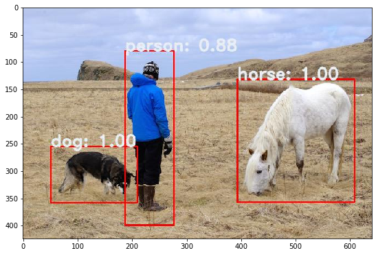

```python
img = cv2.imread('test_imagesout/person.jpg')
img = cv2.cvtColor(img, cv2.COLOR_BGR2RGB)
plt.figure(figsize = (20, 20))
plt.subplot(1, 2, 1); plt.imshow(img)
img.shape
```

```
(576, 768, 3)
```

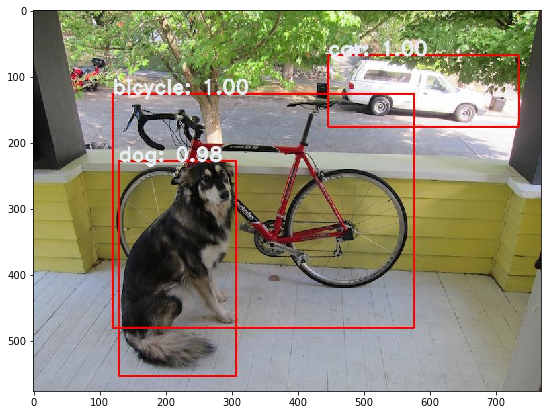

```python
img = cv2.imread('test_imagesout/dog.jpg')
img = cv2.cvtColor(img, cv2.COLOR_BGR2RGB)
plt.figure(figsize = (20, 20))
plt.subplot(1, 2, 1); plt.imshow(img)
img.shape
```

```
(386, 640, 3)
```

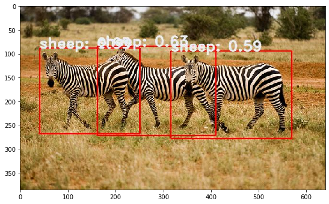

```python
img = cv2.imread('test_imagesout/zebra.jpg')
img = cv2.cvtColor(img, cv2.COLOR_BGR2RGB)
plt.figure(figsize = (20, 20))
plt.subplot(1, 2, 1); plt.imshow(img)
img.shape
```

- 視頻影片 偵測 - Video Detection
- 查看視頻影片
  - Review Orginal Video Clips

```python
%%time

from IPython.display import Video
Video("inputs/videos/car_chase_01.mp4")
```

```
Wall time: 0 ns
```

[video not shown]

- 視頻影片 Video Test
  - Display Video with Detection
  - Detection with nms filter

```python
from IPython.display import Video
Video("outputs/videos/car_chase_01.mp4")
```

[video not shown]

- Convert mp4 to gif
  - https://convertio.co/mp4-gif/

```python
from IPython.display import Image
from IPython.display import display
display(Image(url='outputs/videos/car_chase_01.gif'))
```

[figure not shown]

- WebCam Live-Time Detecting

```python
%%time
video_capture = cv2.VideoCapture(0)
while video_capture.isOpened():
    _, frame = video_capture.read()
    canvas = detect_object(frame)
    cv2.imshow('Video', canvas)
    if cv2.waitKey(1) & 0xFF == ord('q'): # Press q to Escape
        break

video_capture.release()
cv2.destroyAllWindows()
```

```
Wall time: 8.1 s
```

- Vidio Clip Live-Time Detecting
  - 視頻影片 偵測

```python
%%time

input_video_path = 'inputs/videos/car_chase_01.mp4'

video_capture = cv2.VideoCapture(input_video_path)
while video_capture.isOpened():
    _, frame = video_capture.read()
#    print(frame)
    canvas = detect_object(frame)
    cv2.imshow('Video', canvas)
    if cv2.waitKey(1) & 0xFF == ord('q'): # Press q to Escape
        break

video_capture.release()
cv2.destroyAllWindows()
```

```
Wall time: 13.1 s
```